# Time Series Analysis using R

Navankur Verma - navankurverma@gmail.com

23/10/2019

# 1 Libraries used:

```r
library(forecast)
library(TSA)
library(lmtest)
library(tseries)
library(urca)
library(fGarch)
```

# 2 Analysis on Some random Time Series:

```r
all_ts =  read.csv("all_ts.csv")
```

## 2.1 Series X

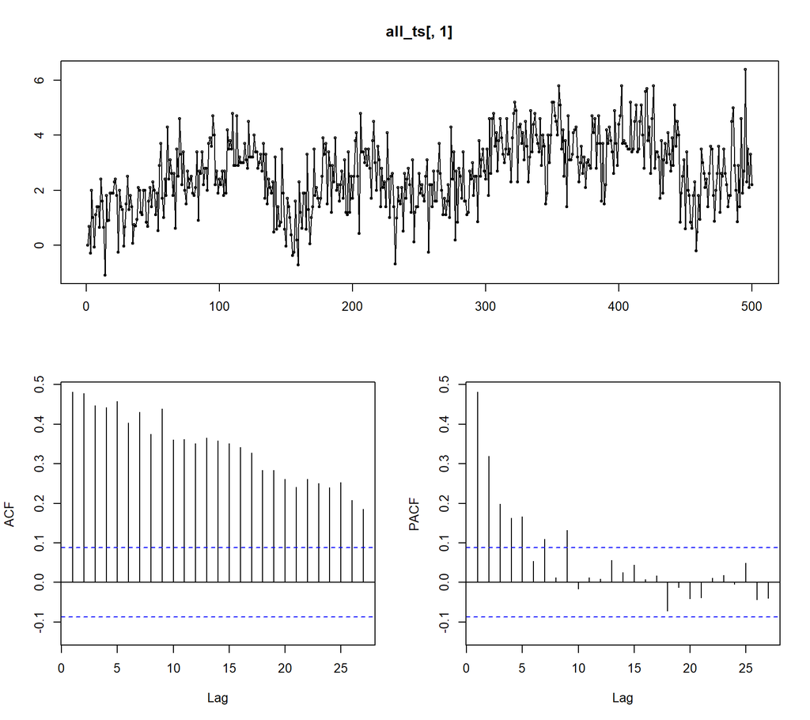

```r
tsdisplay(all_ts[,1])
```

As the ACF of TimeSeries is not decaying exponentially, so we must take its difference to make it stationary.

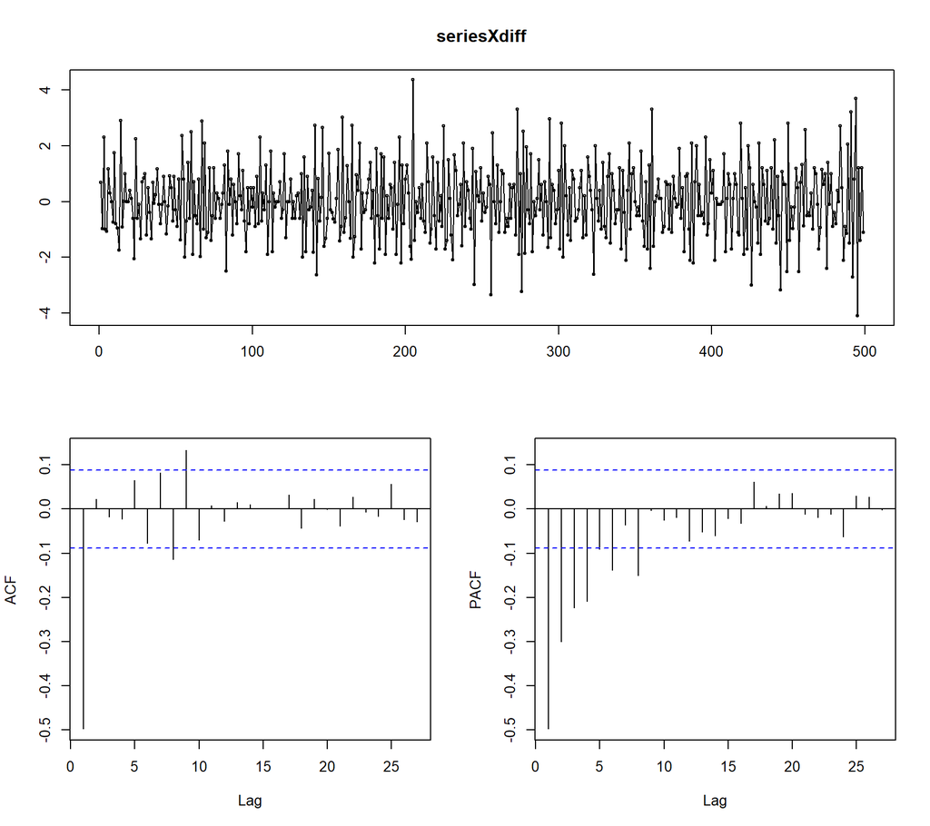

```r
seriesXdiff =  diff(all_ts[,1])
tsdisplay(seriesXdiff)
```

After 1st Differencing ACF and PACF decays exponentially, hence the original TS X is having d=1. As we can see that ACF of differenced TS X is non null after lag 1, hence q = 1. And PACF just tails off, so p = 0.

So the TS X is ARIMA(0,1,1)

## 2.2 Series Y

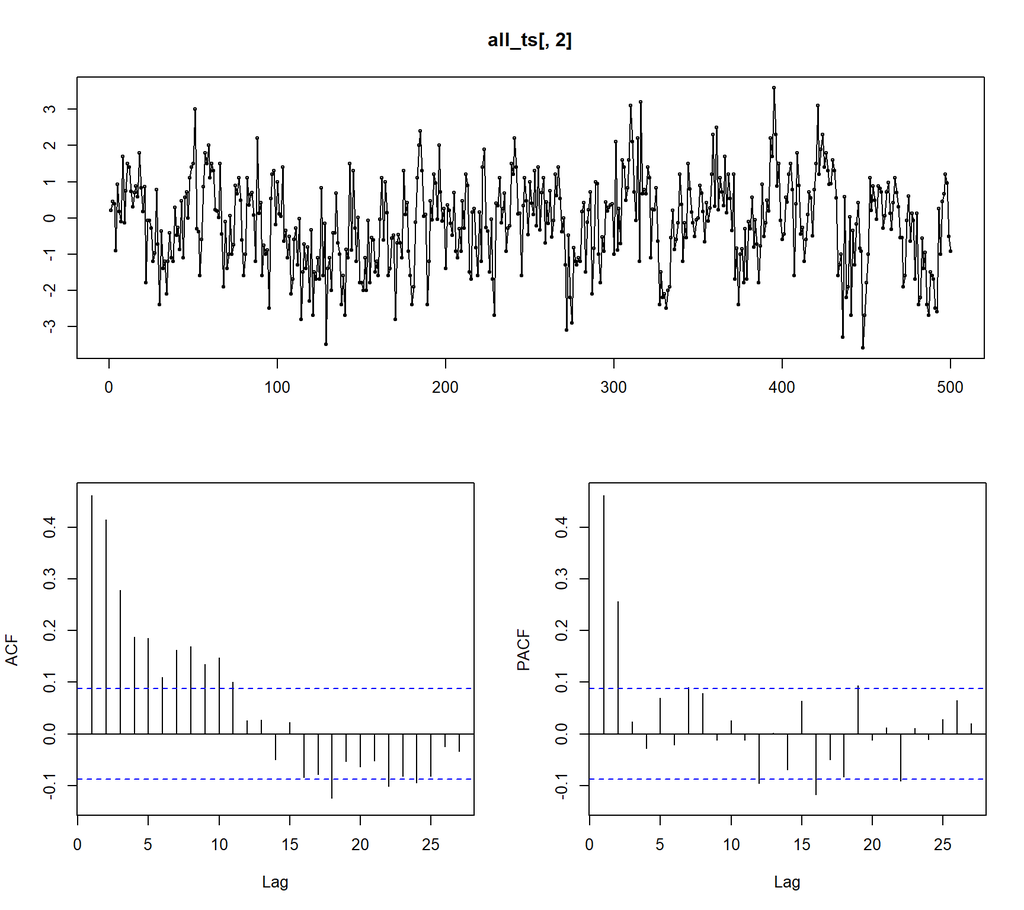

```r
tsdisplay(all_ts[,2])
```

For TS Y, ACF and PACF both decay exponentially, so it is not required to take its difference, d = 0.  
ACF of TS Y is tailing off, so q = 0. PACF is non null for two lags, so p = 2.

So the TS Y is ARIMA(2,0,0)

## 2.3 Parameter estimation of ARIMA models of Time Series X & Y

```r
modX = arima(all_ts[,1],order = c(0,1,1),include.mean = FALSE)
modY =  arima(all_ts[,2],order = c(2,0,0),include.mean = FALSE)

coeftest(modX)
```

```
##
## z test of coefficients:
##
##      Estimate Std. Error z value  Pr(>|z|)
## ma1 -0.824827   0.025328 -32.565 < 2.2e-16 ***
## ---
## Signif. codes:  0 '***' 0.001 '**' 0.01 '*' 0.05 '.' 0.1 ' ' 1
```

```r
coeftest(modY)
```

```
##
## z test of coefficients:
##
##     Estimate Std. Error z value  Pr(>|z|)
## ar1 0.347070   0.043090  8.0545 7.983e-16 ***
## ar2 0.260208   0.043091  6.0386 1.555e-09 ***
## ---
## Signif. codes:  0 '***' 0.001 '**' 0.01 '*' 0.05 '.' 0.1 ' ' 1
```

In the estimated arima models of TS X & Y, p-values for each parameter are very less and hence the estimates are statistically significant.

## 2.4 Series Z

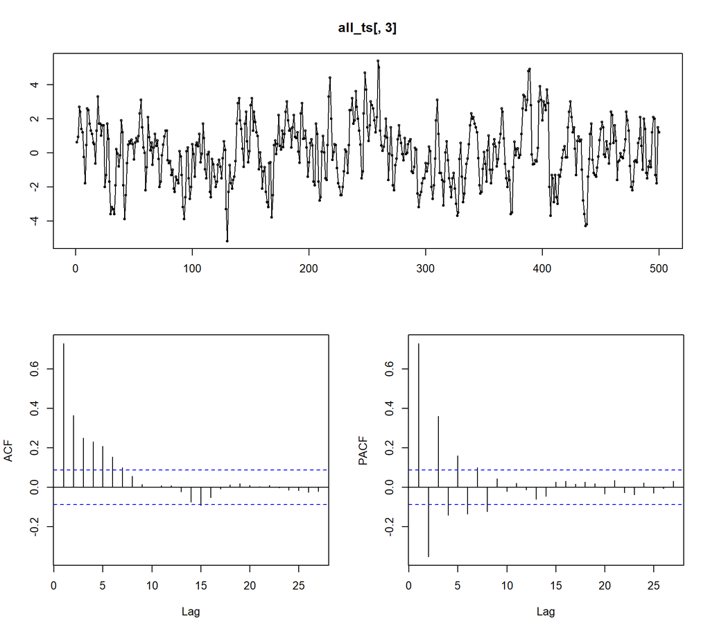

```r
tsdisplay(all_ts[,3])
```

For TS Z, ACF and PACF both decay exponentially, so it is not required to take its difference, d = 0. Both the ACF and PACF are tailing off, so p>0 and q>0. So we have to use build up approach to model this time series.

## 2.5 Parameter estimation of ARIMA models of Time Series Z

```r
modZ11 = arima(all_ts[,3],order = c(1,0,1),include.mean = FALSE)
modZ12 = arima(all_ts[,3],order = c(1,0,2),include.mean = FALSE)
modZ21 = arima(all_ts[,3],order = c(2,0,1),include.mean = FALSE)

coeftest(modZ11)
```

```
##
## z test of coefficients:
##
##     Estimate Std. Error z value  Pr(>|z|)
## ar1 0.456554   0.042733  10.684 < 2.2e-16 ***
## ma1 0.804087   0.027625  29.108 < 2.2e-16 ***
## ---
## Signif. codes:  0 '***' 0.001 '**' 0.01 '*' 0.05 '.' 0.1 ' ' 1
```

```r
coeftest(modZ12)
```

```
##
## z test of coefficients:
##
##      Estimate Std. Error z value  Pr(>|z|)
## ar1  0.527975   0.123222  4.2847 1.830e-05 ***
## ma1  0.717124   0.148199  4.8389 1.305e-06 ***
## ma2 -0.082674   0.138975 -0.5949    0.5519
## ---
## Signif. codes:  0 '***' 0.001 '**' 0.01 '*' 0.05 '.' 0.1 ' ' 1
```

```r
coeftest(modZ21)
```

```
##
## z test of coefficients:
##
##     Estimate Std. Error z value  Pr(>|z|)
## ar1 0.441360   0.055377  7.9700 1.586e-15 ***
## ar2 0.023233   0.054056  0.4298    0.6673
## ma1 0.811964   0.032237 25.1876 < 2.2e-16 ***
## ---
## Signif. codes:  0 '***' 0.001 '**' 0.01 '*' 0.05 '.' 0.1 ' ' 1
```

In ARMA(1,0,2) & ARMA(2,0,1) one of the coefficient (ma2 & ar2 respectively) has large p-value hence we need to drop it and hence we choose the ARMA(1,0,1) model which has significant parameters.

## 2.6 Validation on the fitted models on Time Series Z

First checking residuals for the ARIMA(1,0,1):

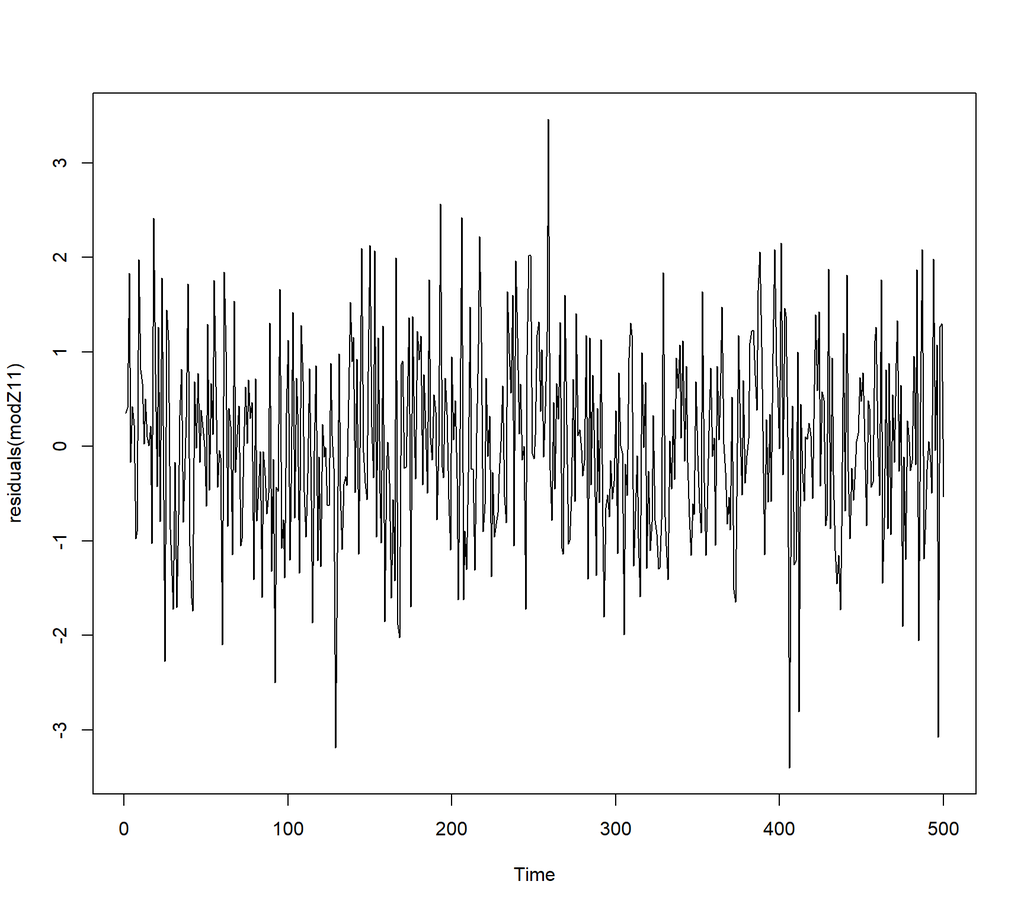

```r
#step1
plot(residuals(modZ11))
```

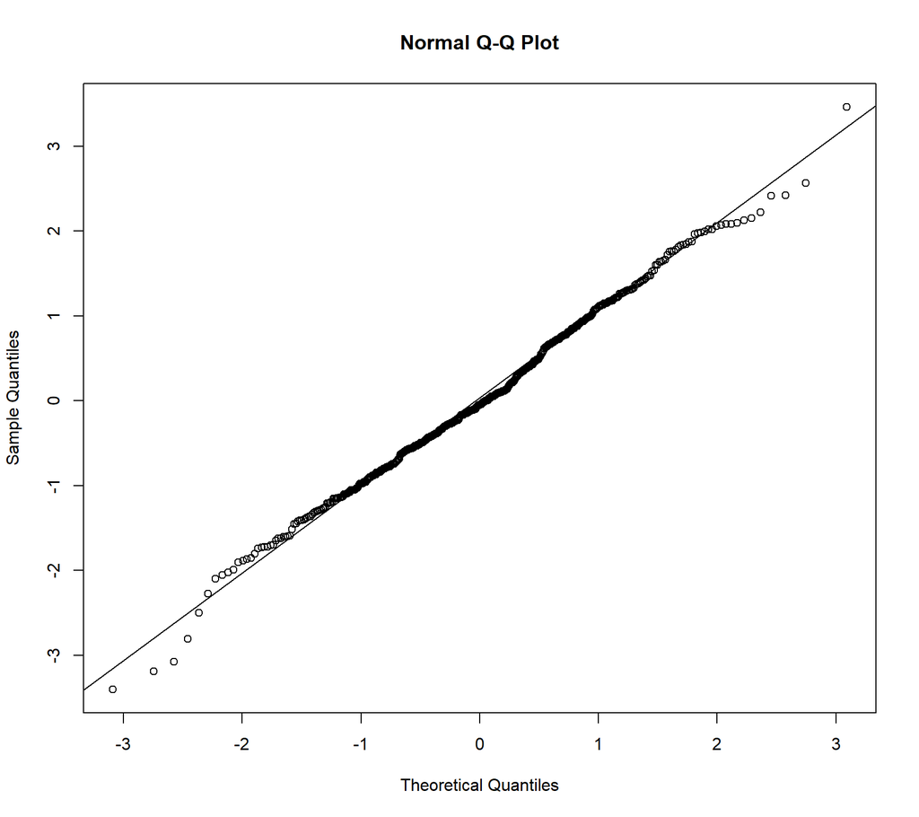

```r
# It looks much like a white noise.

#step2
qqnorm(residuals(modZ11))
qqline(residuals(modZ11))
```

```r
shapiro.test(residuals(modZ11))
```

```
##
##  Shapiro-Wilk normality test
##
## data:  residuals(modZ11)
## W = 0.9958, p-value = 0.2032
```

QQ Plot shows that residuals follow the normal behvaiour and the Shapiro-Wilk test gives the p-value which is greater than 0.05, i.e. we fail to reject null hyposthesis that residuals are normally distributed.

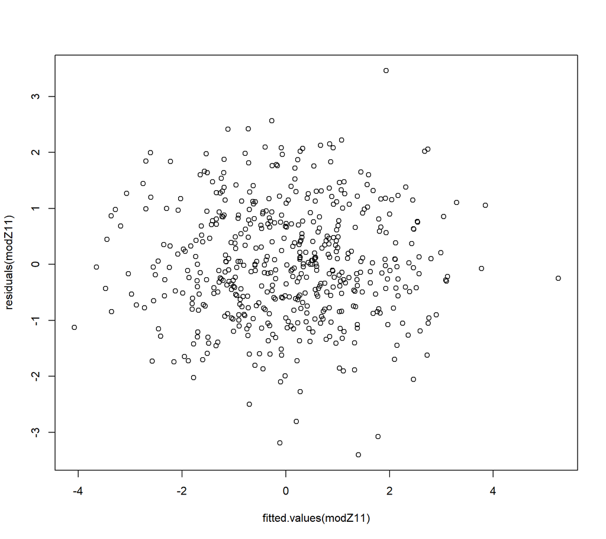

```r
#step3
plot(fitted.values(modZ11),residuals(modZ11))
```

Scatterplot of fitted values and residuals show no pattern.

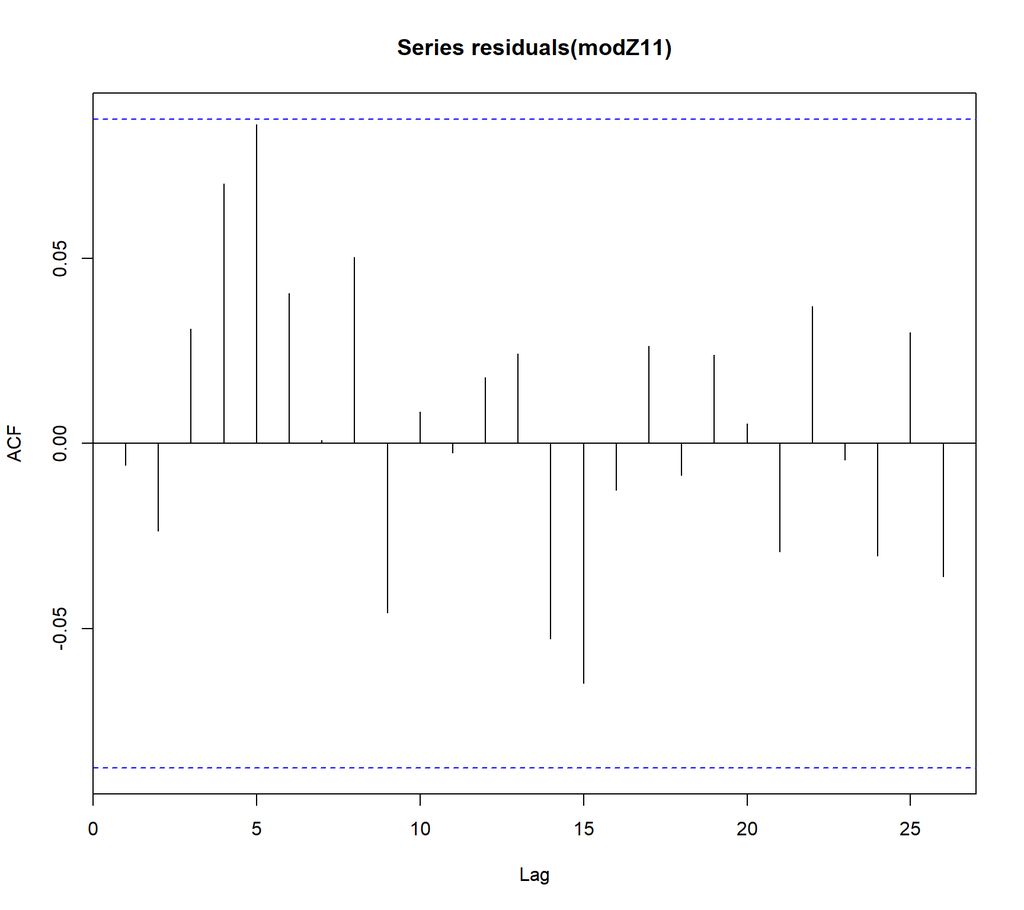

```r
#step4
acf(residuals(modZ11))
```

```r
Box.test(residuals(modZ11), type=c("Ljung-Box") ,lag=12, fitdf=2)
```

```
##
##  Box-Ljung test
##
## data:  residuals(modZ11)
## X-squared = 10.438, df = 10, p-value = 0.4029
```

ACF at lag 5 is nearly non null. But still theoretically we can say it is not required to increase q in ARIMA and Ljung-Box test also gives p-value greater than 0.05 which means there is no correlation in the residuals and this model is suitable.

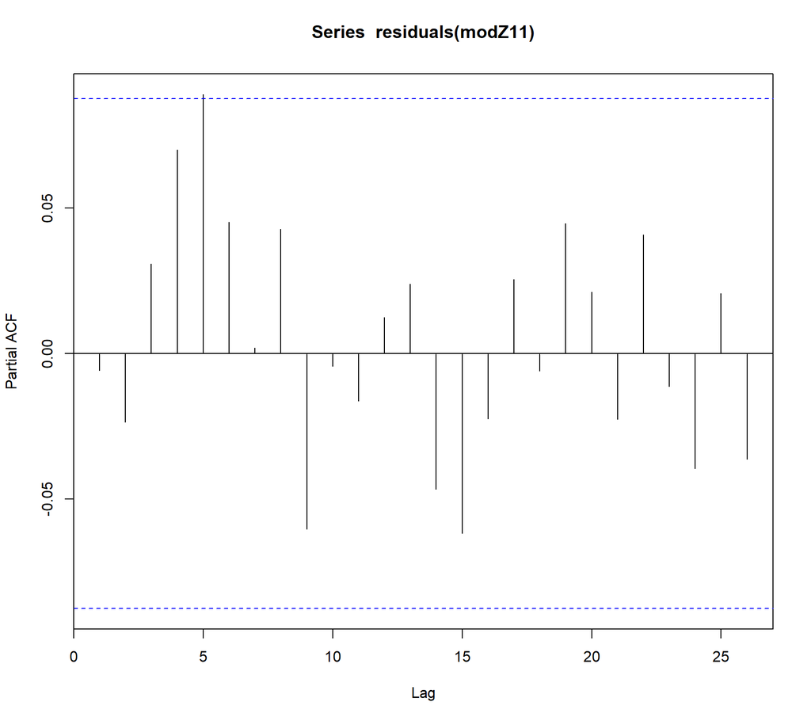

```r
#step5
pacf(residuals(modZ11))
```

PACF at lag 5 is just above the critical level, which suggests to increase p in ARIMA.

Checking residuals for the ARIMA(2,0,0):

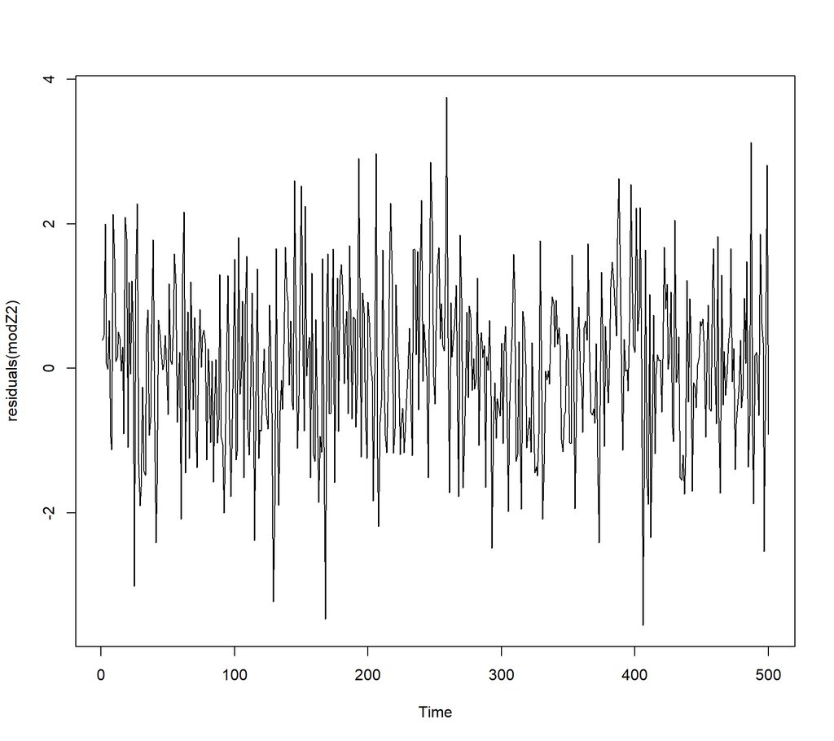

```r
modZ2 = arima(all_ts[,3],order = c(2,0,0),include.mean = FALSE)

#step1
plot(residuals(modZ2))
```

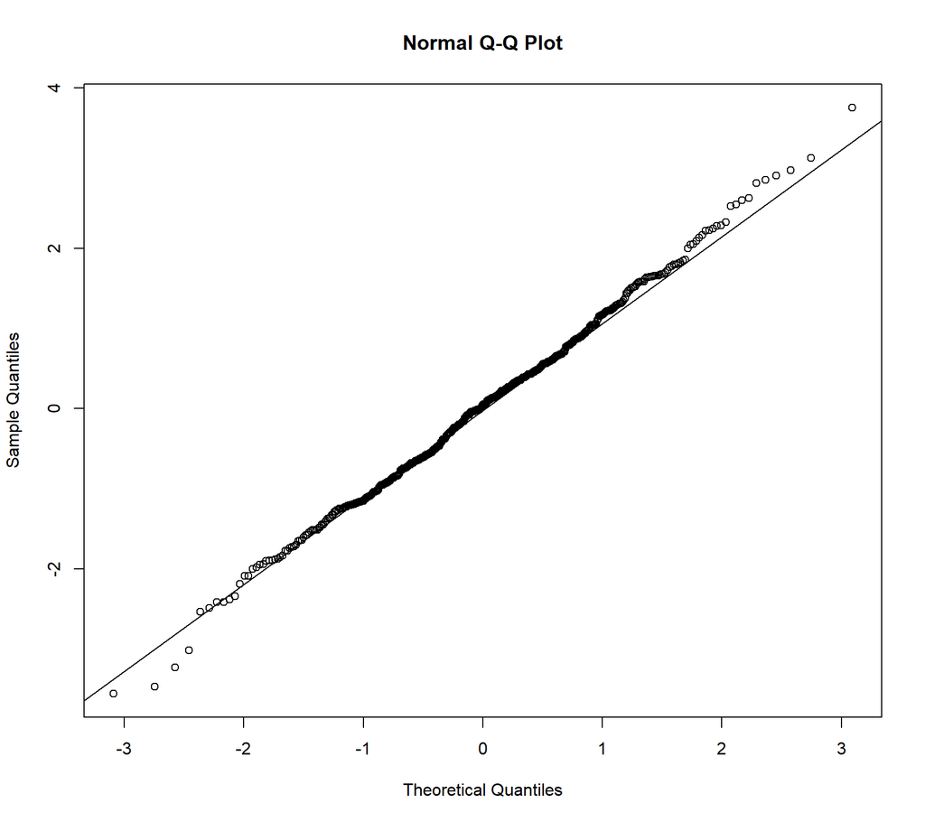

```r
# It looks much like a white noise.

#step2
qqnorm(residuals(modZ2))
qqline(residuals(modZ2))
```

```r
shapiro.test(residuals(modZ2))
```

```
##
##  Shapiro-Wilk normality test
##
## data:  residuals(modZ2)
## W = 0.99757, p-value = 0.6861
```

QQ Plot follows the straight line and the Shapiro-Wilk test gives p-value which is greater than 0.05, so we can say that residuals are normally distributed.

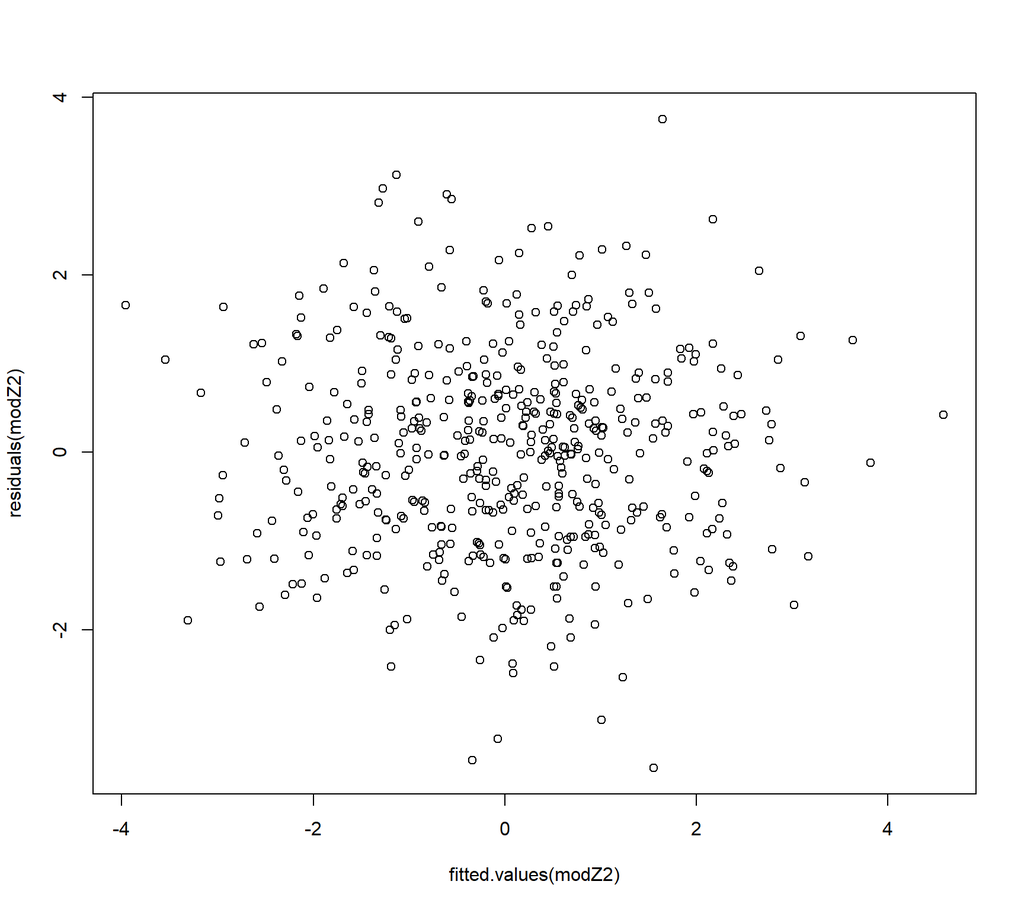

```r
#step3
plot(fitted.values(modZ2),residuals(modZ2))
```

Scatterplot of fitted values and residuals show no pattern.

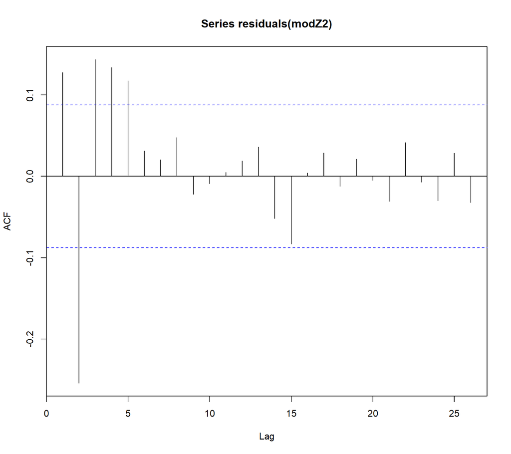

```r
#step4
acf(residuals(modZ2))
```

```r
Box.test(residuals(modZ2), type=c("Ljung-Box") ,lag=12, fitdf=2)
```

```
##
##  Box-Ljung test
##
## data:  residuals(modZ2)
## X-squared = 69.605, df = 10, p-value = 5.285e-11
```

ACF at lags < 6 are all non null, so we might need to increase the q in ARIMA and Ljung-Box test also gives p-value much less than 0.05 which means there is some correlation left in the residuals which should be removed.

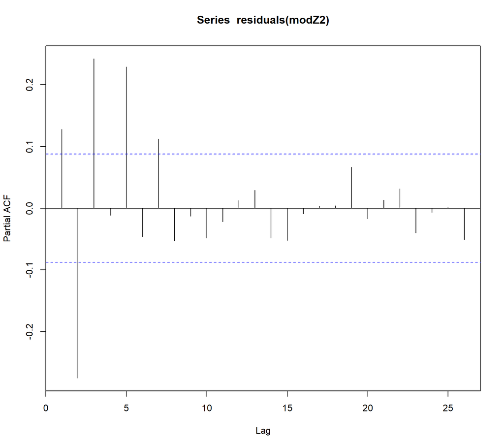

```r
#step5
pacf(residuals(modZ2))
```

PACF at various lags are non null, so we might need to increase the p in ARIMA.

## 2.7 Fitting ARIMA with higher number of Auto Regressive Components:

Fitting with ARIMA(10,0,0) on time series Z:

```r
modZ10 = arima(all_ts[,3],order = c(10,0,0),include.mean = FALSE)

coeftest(modZ10)
```

```
##
## z test of coefficients:
##
##       Estimate Std. Error  z value  Pr(>|z|)
## ar1   1.243151   0.044721  27.7977 < 2.2e-16 ***
## ar2  -1.021776   0.071533 -14.2840 < 2.2e-16 ***
## ar3   0.864821   0.084612  10.2210 < 2.2e-16 ***
## ar4  -0.629263   0.092152  -6.8285 8.578e-12 ***
## ar5   0.559293   0.094632   5.9102 3.417e-09 ***
## ar6  -0.435401   0.094739  -4.5958 4.311e-06 ***
## ar7   0.321994   0.092804   3.4696 0.0005212 ***
## ar8  -0.208950   0.085816  -2.4348 0.0148983 *
## ar9   0.075427   0.072839   1.0355 0.3004238
## ar10 -0.021601   0.045484  -0.4749 0.6348375
## ---
## Signif. codes:  0 '***' 0.001 '**' 0.01 '*' 0.05 '.' 0.1 ' ' 1
```

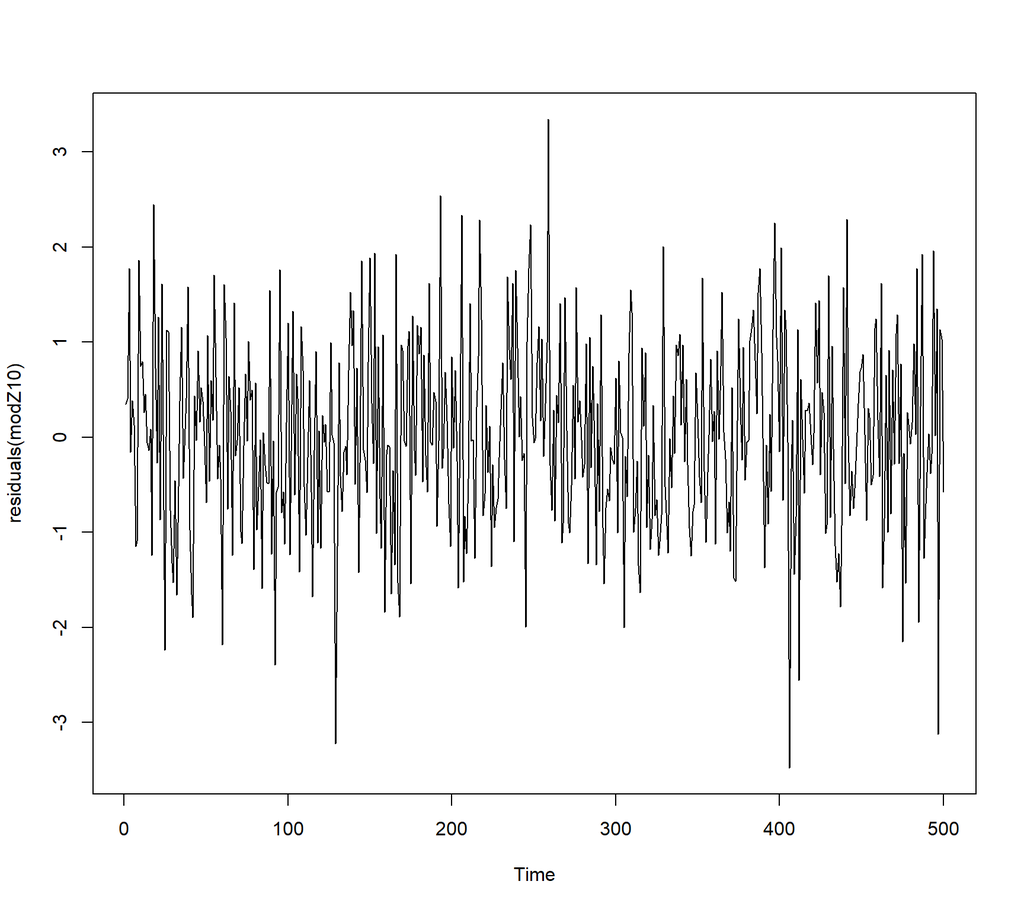

```r
#step1
plot(residuals(modZ10))
```

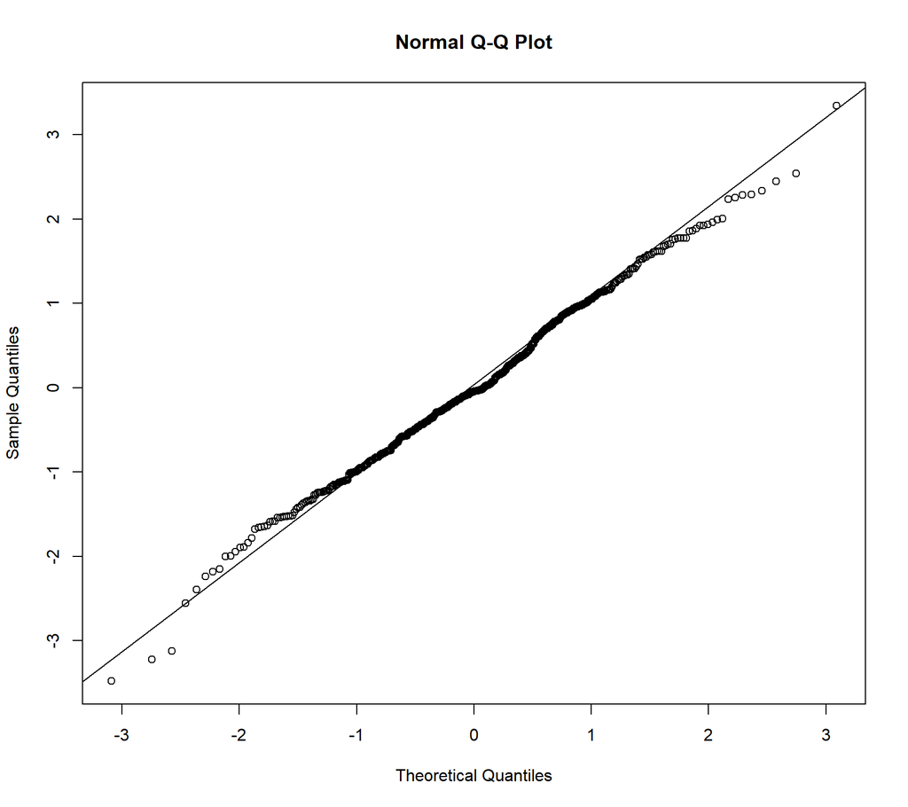

```r
# It looks much like a white noise.

#step2
qqnorm(residuals(modZ10))
qqline(residuals(modZ10))
```

```r
shapiro.test(residuals(modZ10))
```

```
##
##  Shapiro-Wilk normality test
##
## data:  residuals(modZ10)
## W = 0.99586, p-value = 0.2136
```

QQ Plot follows the straight line and the Shapiro-Wilk test gives p-value which is greater than 0.05, so we can say that residuals are normally distributed.

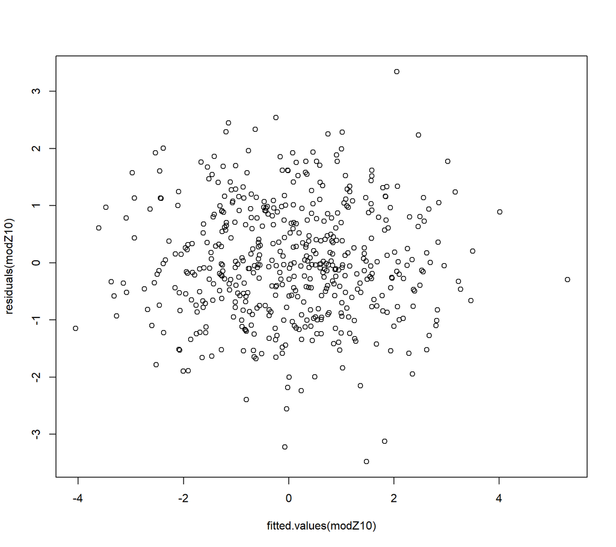

```r
#step3
plot(fitted.values(modZ10),residuals(modZ10))
```

Scatterplot of fitted values and residuals show no pattern.

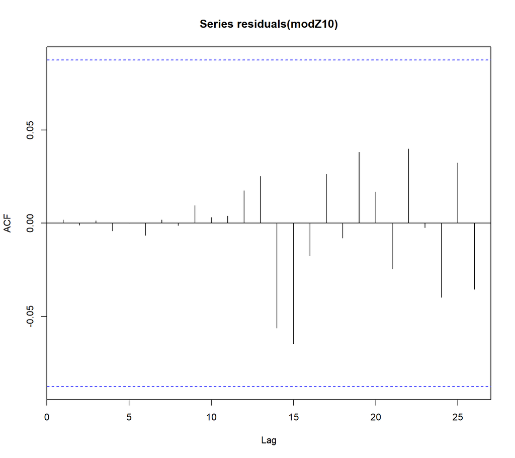

```r
#step4
acf(residuals(modZ10))
```

```r
Box.test(residuals(modZ10), type=c("Ljung-Box") ,lag=20, fitdf=10)
```

```
##
##  Box-Ljung test
##
## data:  residuals(modZ10)
## X-squared = 5.8535, df = 10, p-value = 0.8274
```

ACF is null at every lag, so we dont need to increase the q in ARIMA and Ljung-Box test large p-value confirms that the residuals are independent and uncorrelated.

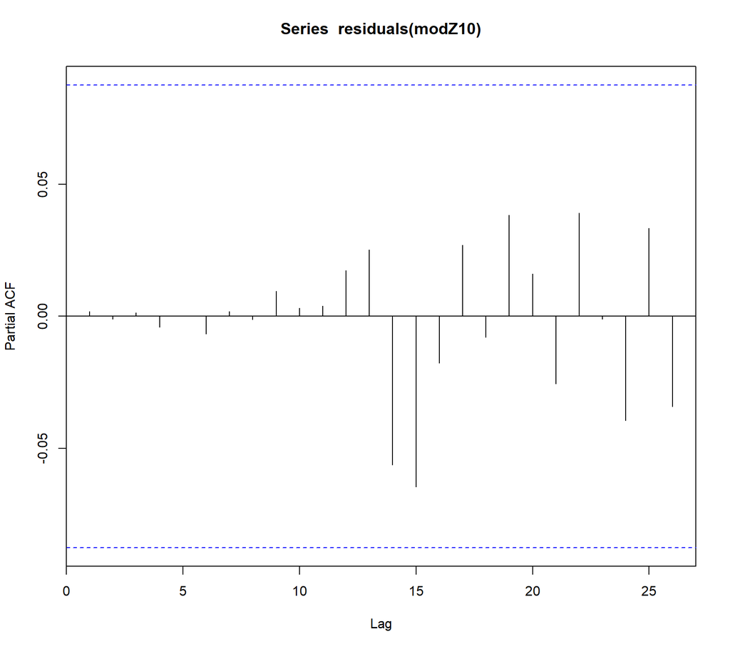

```r
#step5
pacf(residuals(modZ10))
```

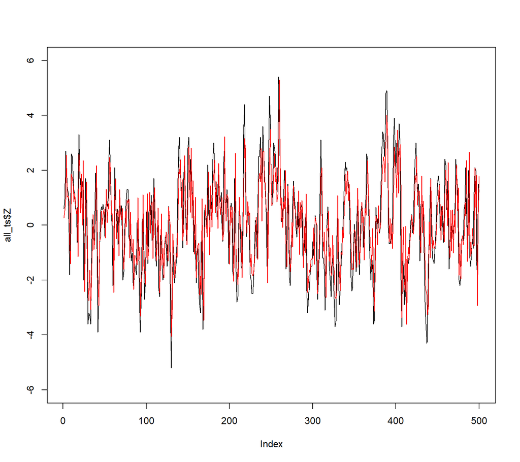

```r
plot(all_ts$Z,type = 'l', ylim = c(-6,6))
lines(fitted.values(modZ10),type = 'l',col = 'red')
```

Plotting the fitted values suggests that model AR10 follows the original timeseries very well. But coeftest also suggests that parameters greater than ar7 are not significant but that is due to overfitting where the estimation becomes unstable and some coefficients are resulting into non significant.

# 3 Trend Stationarity:

Time Series:Monthly U.S. average prescription costs for the months 08/1986 - 03/1992

**Is it stationary?**

```r
data("prescrip")

tseries::adf.test(prescrip, k = 0)
```

```
##
##  Augmented Dickey-Fuller Test
##
## data:  prescrip
## Dickey-Fuller = -2.7968, Lag order = 0, p-value = 0.2515
## alternative hypothesis: stationary
```

p-value is greater than 0.05, so we fail to reject the null-hypothesis. There is a unit root and we need to take difference.

**F-statistic:**

$\phi_{3}$ test statistic for the test whether ($\alpha,\beta,\phi$) = ($\alpha,0,1$) in the model given by:

$X_{t} = \alpha + \beta t + \phi X_{t-1} + \epsilon_{t}$

where $X_{t}$ is the average prescription cost in month $t$.

```r
n = length(prescrip)
tt = 2:n
prescrip[-n]
```

```
##  [1] 14.5471 14.6721 14.8016 14.6125 14.2967 14.3250 14.6231 15.1362 15.2200
## [10] 15.7592 16.0724 16.1126 16.1826 16.4537 15.9885 16.1646 16.6733 16.5005
## [19] 16.8483 16.5935 17.4391 17.9894 17.8031 18.5141 18.8180 19.2117 18.9650
## [28] 18.7972 19.1667 18.9739 18.5933 19.3313 20.1503 20.9867 21.1868 21.8878
## [37] 21.8578 22.4741 22.1601 21.9503 21.9989 21.8922 22.2364 23.0349 23.4658
## [46] 24.6513 24.7339 25.2870 25.3264 25.7877 25.1988 25.4100 25.2900 24.5715
## [55] 24.2925 25.4905 26.1685 27.0857 27.4766 28.2164 27.9908 28.1535 27.5391
## [64] 27.9092 26.8256 27.9715 29.4773
```

```r
y = diff(prescrip)

fit = lm(y~tt+prescrip[-n])
yhat = fitted(fit)

phi3 = sum((yhat-mean(y))^2)/2/(sum((y-yhat)^2)/64)
phi3
```

```
## [1] 4.861987
```

```r
summary(ur.df(prescrip,type = 'trend', lags = 0))
```

```
##
## ###############################################
## # Augmented Dickey-Fuller Test Unit Root Test #
## ###############################################
##
## Test regression trend
##
##
## Call:
## lm(formula = z.diff ~ z.lag.1 + 1 + tt)
##
## Residuals:
##      Min       1Q   Median       3Q      Max
## -1.44289 -0.33147  0.01302  0.33358  1.04300
##
## Coefficients:
##             Estimate Std. Error t value Pr(>|t|)
## (Intercept)  3.17952    1.10825   2.869  0.00557 **
## z.lag.1     -0.23663    0.08461  -2.797  0.00681 **
## tt           0.05913    0.01987   2.975  0.00413 **
## ---
## Signif. codes:  0 '***' 0.001 '**' 0.01 '*' 0.05 '.' 0.1 ' ' 1
##
## Residual standard error: 0.4816 on 64 degrees of freedom
## Multiple R-squared:  0.1319, Adjusted R-squared:  0.1048
## F-statistic: 4.862 on 2 and 64 DF,  p-value: 0.01082
##
##
## Value of test-statistic is: -2.7968 8.8117 4.862
##
## Critical values for test statistics:
##       1pct  5pct 10pct
## tau3 -4.04 -3.45 -3.15
## phi2  6.50  4.88  4.16
## phi3  8.73  6.49  5.47
```

Here we checked if Time series along with being difference stationary, does it also have any trend in it or not.

# 4 Seasonality

Time Series: Monthly beer sales in millions of barrels, 01/1975 - 12/1990.

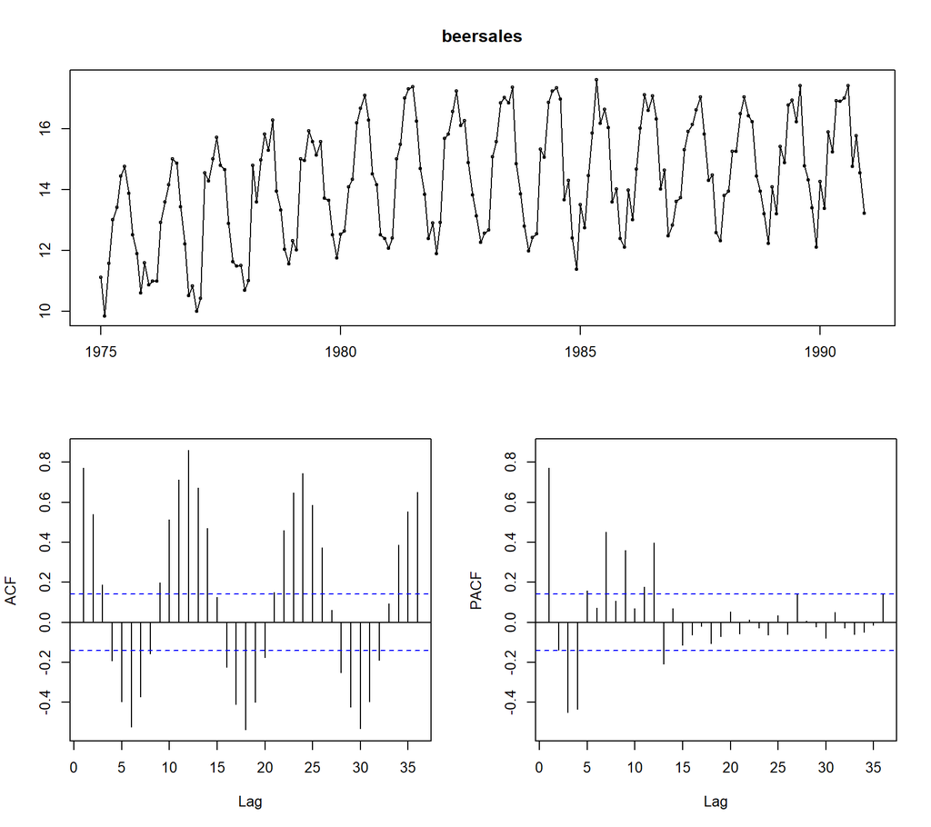

```r
data(beersales)
tsdisplay(beersales)
```

```r
adf.test(beersales)
```

```
##
##  Augmented Dickey-Fuller Test
##
## data:  beersales
## Dickey-Fuller = -9.7734, Lag order = 5, p-value = 0.01
## alternative hypothesis: stationary
```

The time series has a seasonal component, which can be seen directly and also from the ACF where correlation has a periodic nature with lags with periodicity of 12 . There is also an linear trend in Time Series. The p-value in the Augmented Dickey-Fuller test is less than 0.01 so we reject the null hypothesis that there is a unit root. Thus the series is not integrated.

**Estimating trend by smoothing the series:**

Since the ACF of the timeseries has periodicity of 12 lags, hence we can choose moving average of order 12.

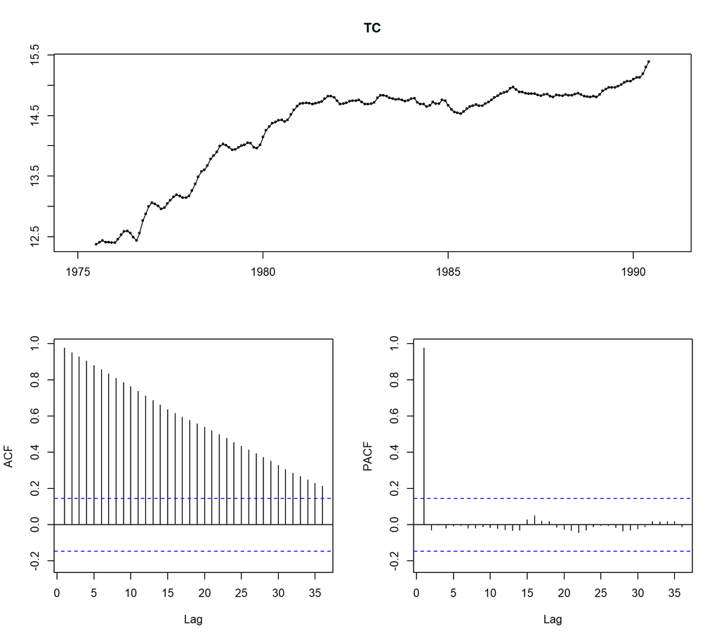

```r
TC = ma(beersales,12)
tsdisplay(TC)
```

**Decompose the time series as an additive model:**

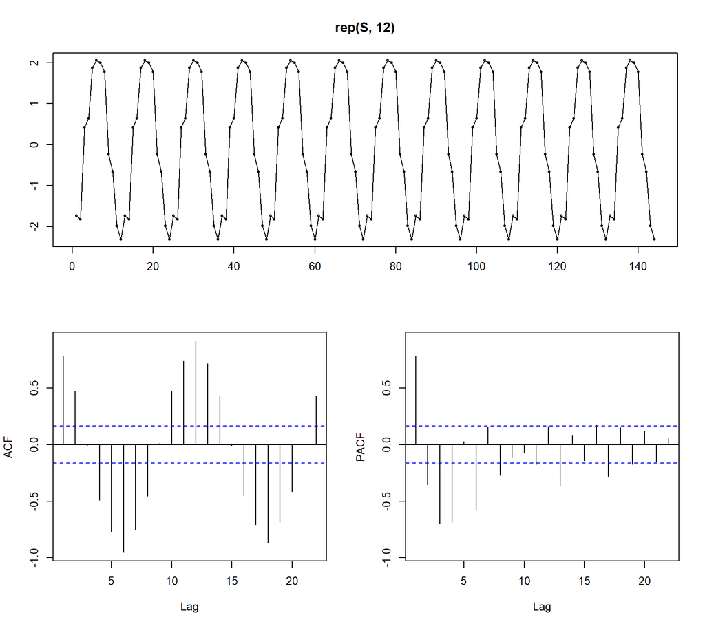

```r
pseudo_s = (beersales - TC) - mean(beersales - TC,na.rm = TRUE)
matrix_s = matrix(pseudo_s,nrow = 12)

S = rowMeans(matrix_s, na.rm = TRUE)

tsdisplay(rep(S,12))
```

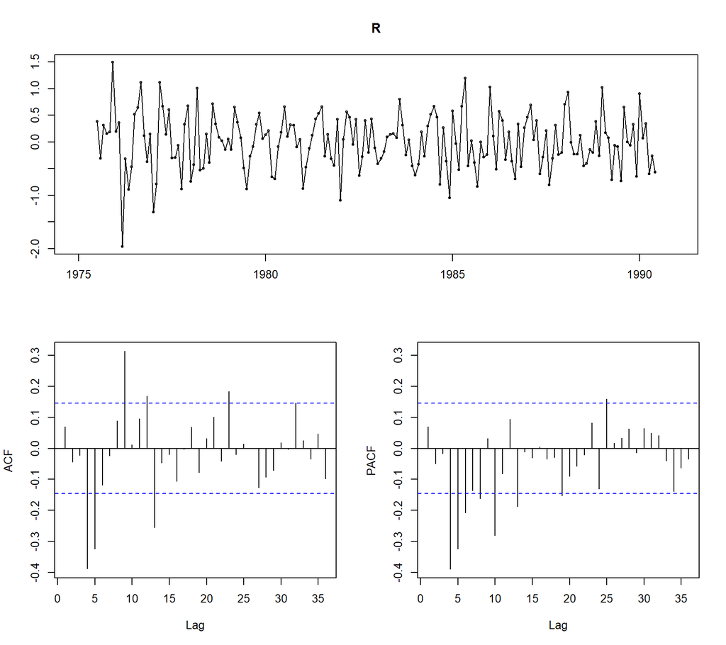

```r
R = beersales - TC - S

tsdisplay(R)
```

# 5 ARIMA-GARCH

Time Series: Daily returns of the google stock from 08/20/04 - 09/13/06

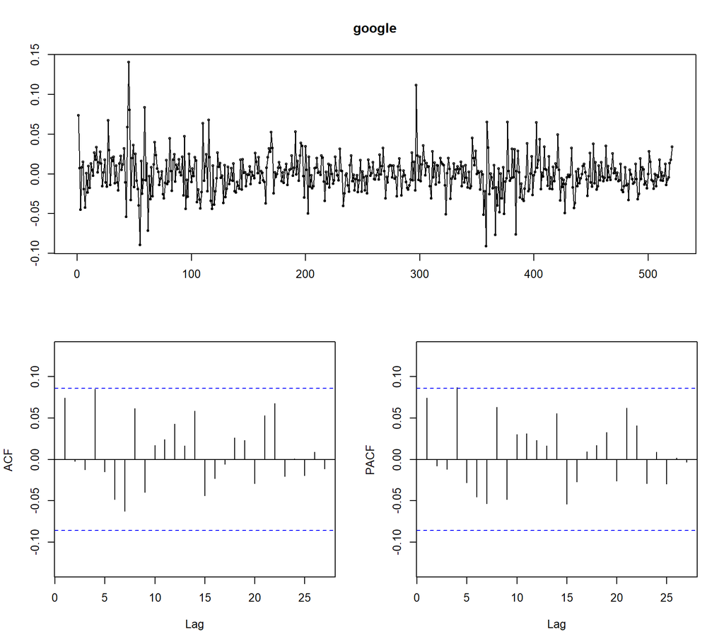

```r
data("google")
google = google - mean(google,na.rm = TRUE)

tsdisplay(google)
```

There seems to be some points where the variations in the timeseries is quite large as compared to other periods.

```r
tseries::adf.test(google)
```

```
##
##  Augmented Dickey-Fuller Test
##
## data:  google
## Dickey-Fuller = -7.982, Lag order = 8, p-value = 0.01
## alternative hypothesis: stationary
```

p-value less than 0.05, so we reject null hypothesis (w = 0 or phi = 1). So the timeseries is stationary and no need for differencing.

From ACF and PACF it can be clearly seen that at all lags values are less than critical value. So we fit the (0,0,0) model.

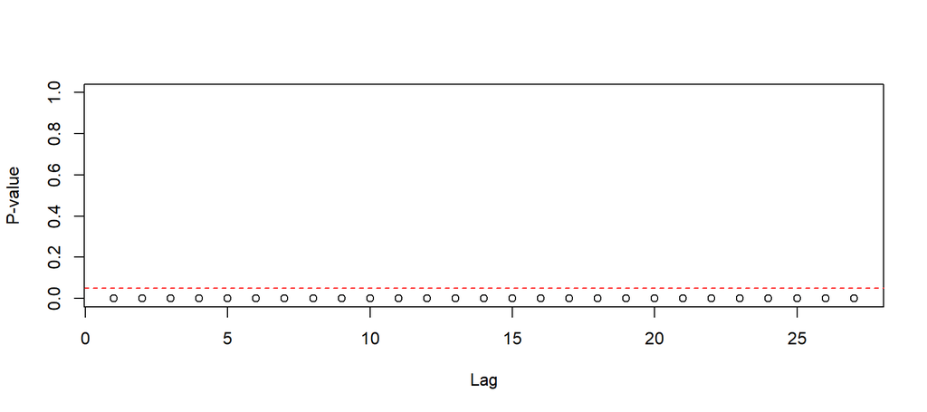

```r
modg = arima(google,order = c(0,0,0))
McLeod.Li.test(y=residuals(modg))
```

At all lags the p-value is below critical value(0.05). We rejet the null hypothesis that there is no autocorrelation in residuals. Hence we conclude that there is some autocorrelation in residuals. Time Series is conditional heteroskedastic.

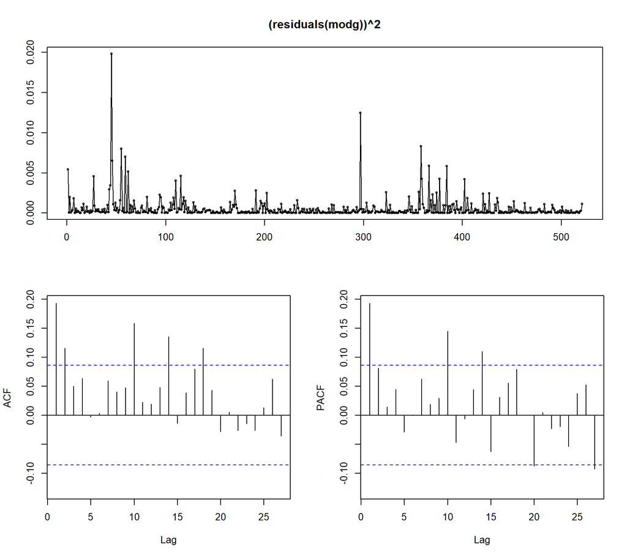

```r
tsdisplay((residuals(modg))^2)
```

ACF plot seems to have 2 non nulls but it can be exponential tail off as well PACF plot seems to have 1 non nulls

```r
fitg10 = garchFit(~arma(0,0)+garch(1,0),google,include.mean = FALSE)
```

[output not shown]

[output cut: 15 more lines]

[output not shown]

```r
summary(fitg10)
```

```
##
## Title:
##  GARCH Modelling
##
## Call:
##  garchFit(formula = ~arma(0, 0) + garch(1, 0), data = google,
##     include.mean = FALSE)
##
## Mean and Variance Equation:
##  data ~ arma(0, 0) + garch(1, 0)
## <environment: 0x0000000023576e28>
##  [data = google]
##
## Conditional Distribution:
##  norm
##
## Coefficient(s):
##      omega      alpha1
## 0.00045323  0.21051211
##
## Std. Errors:
##  based on Hessian
##
## Error Analysis:
##         Estimate  Std. Error  t value Pr(>|t|)
## omega  4.532e-04   3.691e-05   12.279  < 2e-16 ***
## alpha1 2.105e-01   7.179e-02    2.932  0.00337 **
## ---
## Signif. codes:  0 '***' 0.001 '**' 0.01 '*' 0.05 '.' 0.1 ' ' 1
##
## Log Likelihood:
##  1220.27    normalized:  2.342169
##
## Description:
##  Sun May 24 21:13:33 2020 by user: Navankur
##
##
## Standardised Residuals Tests:
##                                 Statistic p-Value
##  Jarque-Bera Test   R    Chi^2  171.8793  0
##  Shapiro-Wilk Test  R    W      0.9649166 8.019453e-10
##  Ljung-Box Test     R    Q(10)  15.45629  0.1162905
##  Ljung-Box Test     R    Q(15)  19.95652  0.1736071
##  Ljung-Box Test     R    Q(20)  20.91325  0.4022544
##  Ljung-Box Test     R^2  Q(10)  21.4502   0.01816404
##  Ljung-Box Test     R^2  Q(15)  31.87076  0.006704001
##  Ljung-Box Test     R^2  Q(20)  42.47288  0.002398588
##  LM Arch Test       R    TR^2   18.62256  0.09805348
##
## Information Criterion Statistics:
##       AIC       BIC       SIC      HQIC
## -4.676660 -4.660323 -4.676689 -4.670261
```

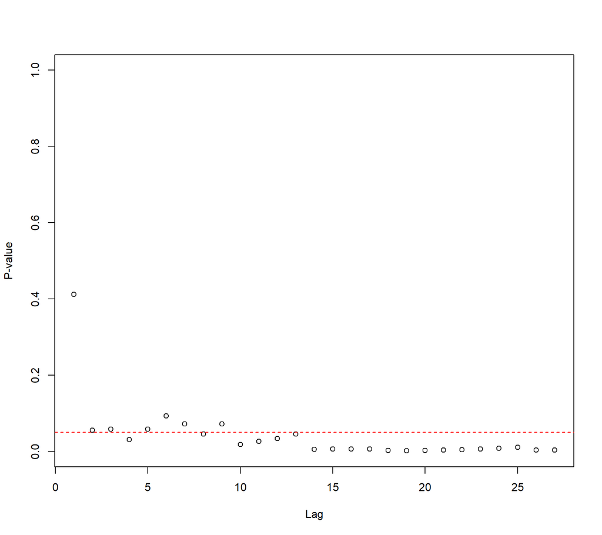

```r
McLeod.Li.test(y=(fitg10@residuals/fitg10@sigma.t))
```

```r
fitg11 = garchFit(~arma(0,0)+garch(1,1),google,include.mean = FALSE)
```

[output not shown]

[output cut: 27 more lines]

[output not shown]

```r
summary(fitg11)
```

```
##
## Title:
##  GARCH Modelling
##
## Call:
##  garchFit(formula = ~arma(0, 0) + garch(1, 1), data = google,
##     include.mean = FALSE)
##
## Mean and Variance Equation:
##  data ~ arma(0, 0) + garch(1, 1)
## <environment: 0x0000000024199d90>
##  [data = google]
##
## Conditional Distribution:
##  norm
##
## Coefficient(s):
##      omega      alpha1       beta1
## 5.2781e-05  1.4171e-01  7.6837e-01
##
## Std. Errors:
##  based on Hessian
##
## Error Analysis:
##         Estimate  Std. Error  t value Pr(>|t|)
## omega  5.278e-05   2.046e-05    2.579  0.00990 **
## alpha1 1.417e-01   4.439e-02    3.192  0.00141 **
## beta1  7.684e-01   6.423e-02   11.964  < 2e-16 ***
## ---
## Signif. codes:  0 '***' 0.001 '**' 0.01 '*' 0.05 '.' 0.1 ' ' 1
##
## Log Likelihood:
##  1235.914    normalized:  2.372197
##
## Description:
##  Sun May 24 21:13:34 2020 by user: Navankur
##
##
## Standardised Residuals Tests:
##                                 Statistic p-Value
##  Jarque-Bera Test   R    Chi^2  197.9118  0
##  Shapiro-Wilk Test  R    W      0.9683952 3.688883e-09
##  Ljung-Box Test     R    Q(10)  11.78695  0.2995681
##  Ljung-Box Test     R    Q(15)  16.42109  0.3546311
##  Ljung-Box Test     R    Q(20)  17.22032  0.6386243
##  Ljung-Box Test     R^2  Q(10)  5.091377  0.8849909
##  Ljung-Box Test     R^2  Q(15)  8.717807  0.8918041
##  Ljung-Box Test     R^2  Q(20)  13.24386  0.8666774
##  LM Arch Test       R    TR^2   5.023359  0.9571942
##
## Information Criterion Statistics:
##       AIC       BIC       SIC      HQIC
## -4.732877 -4.708372 -4.732943 -4.723278
```

Coefficients are signigicant and p-value is also large for LM Test. So we fail to reject the null hypothesis that there is no autocorrelation. McLeod Li test also confirms the same:

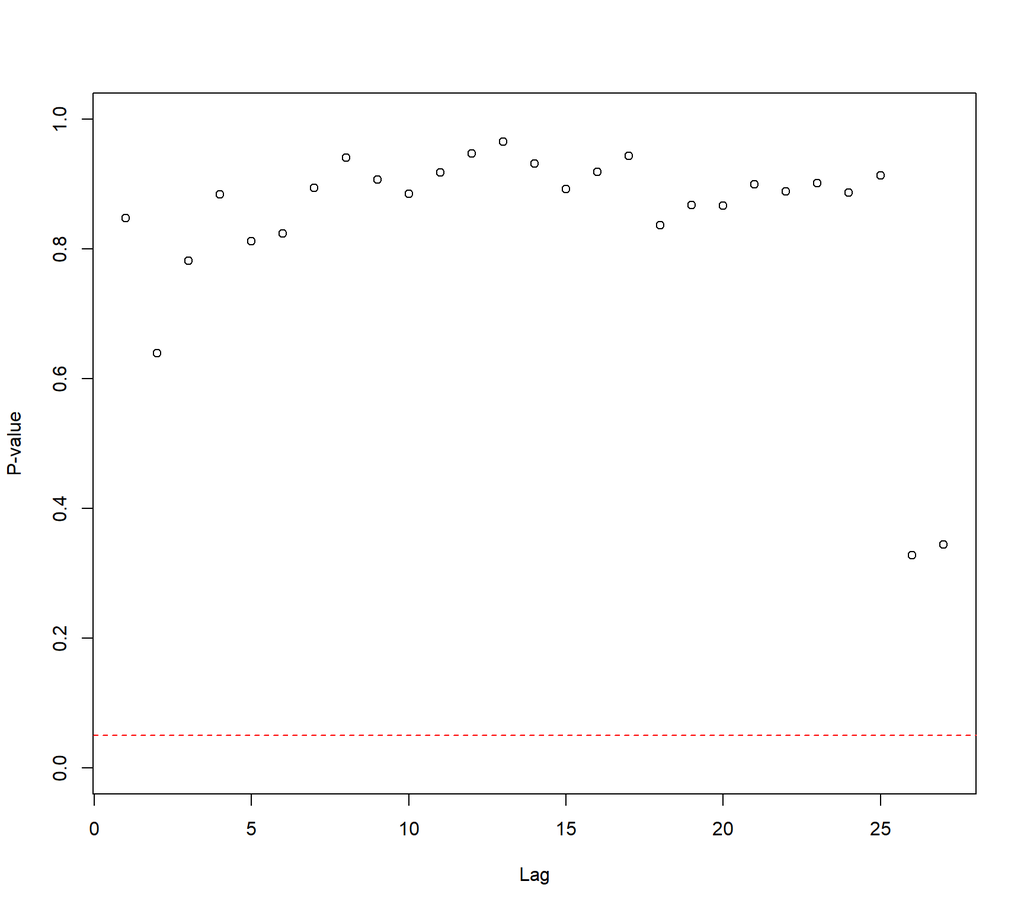

```r
McLeod.Li.test(y=(fitg11@residuals/fitg11@sigma.t))
```

It can be concluded that give time series is a ARMA(0,0) + GARCH(1,1) model.

**Conditional variances and Standardised residuals:**

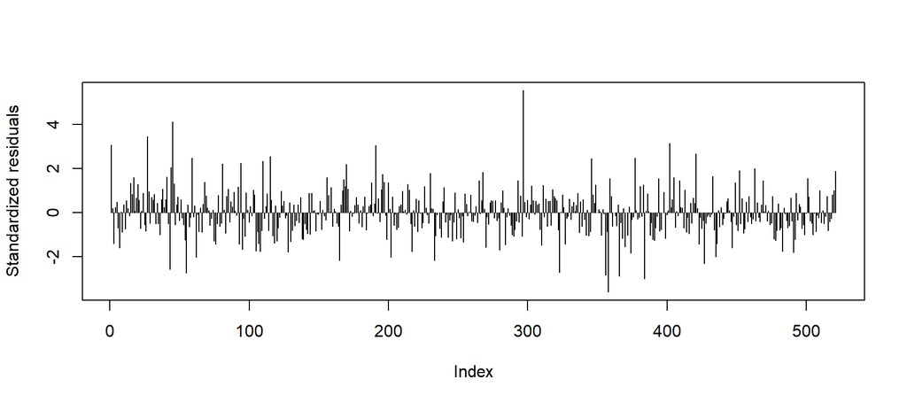

```r
plot(fitg11@residuals/fitg11@sigma.t,t = 'h',ylab = "Standardized residuals")
```

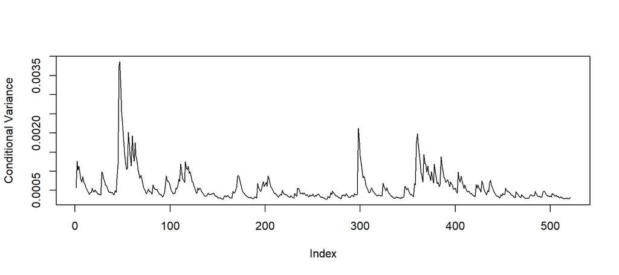

```r
plot((fitg11@sigma.t)^2,t = 'l',ylab = "Conditional Variance")
```